# Workflow_A_Peng - R Notebook

# Como converter objeto Anndata para Seurat (reproduzir essa parte no Python) –> Exemplo Sanbomics

# Existem algumas formas de conversão direta entre um objeto Anndata para Seurat preservando toda análise, mas surgiram alguns erros e problemas no output final

# Apesar de mais trabalhoso, recomendo converter os arquivos brutos e realizar análise do começo ao fim

# Criamos um diretório para salvar os arquivos (barcodes, features e matrix)

!mkdir matrix_files

# Salvando barcodes, features e matrix

io.mmwrite(‘matrix_files/matrix’, adata.X.T)

# Salvando o metadata

adata.obs.to_csv(‘matrix_files/metadata.csv’)

# Aqui já é diretamente no R

# Pacotes

```r
library(BiocManager)
library(tidyverse)
library(dplyr)
library(ggplot2)
library(Matrix)
library(Seurat)
library(UCell)
```

# Carregando o metadata. Aqui já temos as doublets identificadas e vamos removê-las

```r
metadata <- read.csv("D:/Scanpy/Workflow_A/metadata_workflow_peng.csv")
```

# Por configurações diferentes entre Python e R, os barcodes estão na primeira coluna e não em rownames

# Arrumamos isso e deletamos a coluna

```r
rownames(metadata) <- metadata$X
metadata$X <- NULL
View(metadata)
```

# Importando os barcodes, features e matrix

```r
counts <- readMM("D:/Scanpy/peng_to_seurat/matrix.mtx")
genes <- read_tsv("D:/Scanpy/peng_to_seurat/features.tsv", col_names = FALSE)
cell_ids <- read_tsv("D:/Scanpy/peng_to_seurat/barcodes.tsv", col_names = FALSE)
```

# Configurando a matriz para que nas linhas (rownames) tenhamos os genes e nas colunas (colnames) os barcodes

```r
rownames(counts) <- genes$X1
colnames(counts) <- cell_ids$X1
```

# Criando o objeto Seurat

```r
sobj <- CreateSeuratObject(counts = counts, meta.data = metadata)
```

# Vamos iniciar removendo as doublets

```r
sobj <- SetIdent(sobj, value = sobj$doublet_pred)
sobj <- subset(sobj, idents = "singlet")
sobj
```

```
An object of class Seurat
18008 features across 57447 samples within 1 assay
Active assay: RNA (18008 features, 0 variable features)
```

# Vamos plotar os gráficos de QC (quality-control)

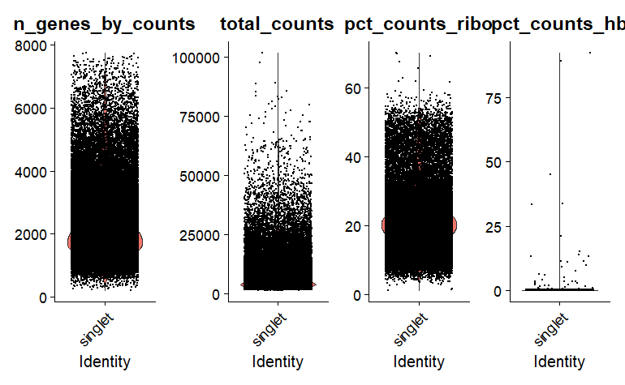

```r
VlnPlot(sobj, features = c("n_genes_by_counts", "total_counts", "pct_counts_ribo", "pct_counts_hb"), ncol = 4)
```

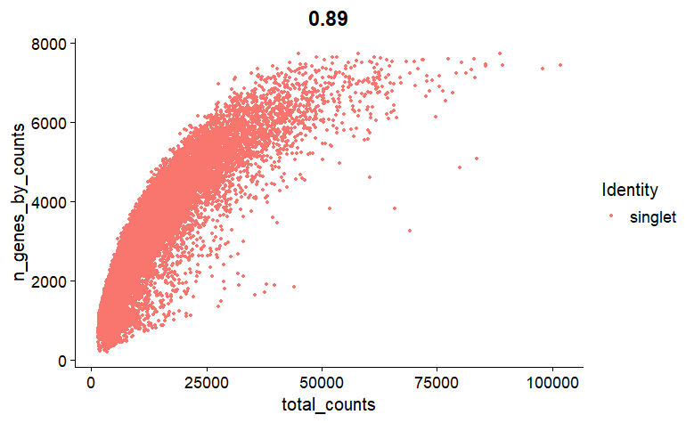

```r
FeatureScatter(sobj, feature1 = "total_counts", feature2 = "n_genes_by_counts")
```

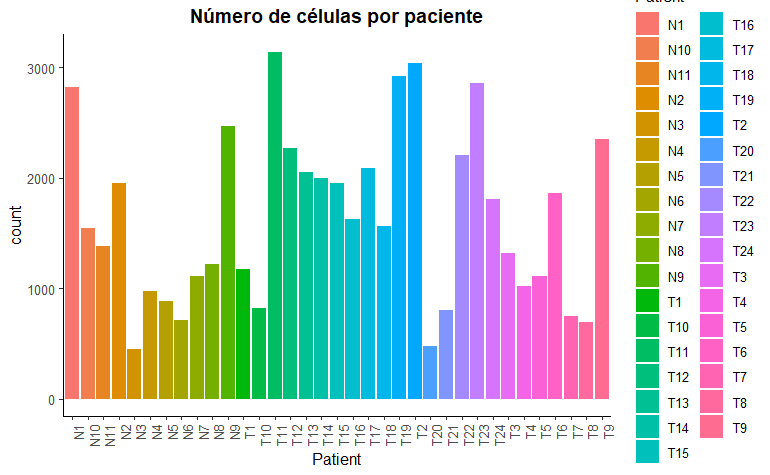

```r
metadata <- sobj@meta.data

metadata %>%
  ggplot(aes(x=Patient, fill=Patient)) +
  geom_bar() +
  theme_classic() +
  theme(axis.text.x = element_text(angle = 90, vjust = 1, hjust=1)) +
  theme(plot.title = element_text(hjust=0.5, face="bold")) +
  ggtitle("Número de células por paciente")
```

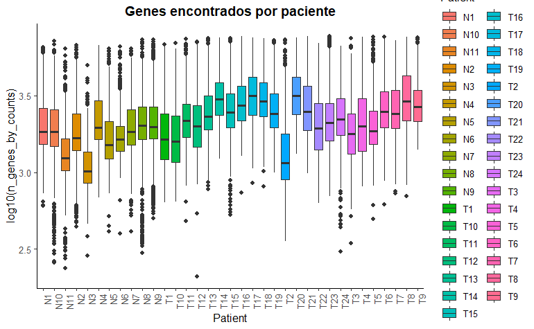

```r
metadata %>%
  ggplot(aes(x=Patient, y=log10(n_genes_by_counts), fill=Patient)) +
  geom_boxplot() +
  theme_classic() +
  theme(axis.text.x = element_text(angle = 90, vjust = 1, hjust=1)) +
  theme(plot.title = element_text(hjust=0.5, face="bold")) +
  ggtitle("Genes encontrados por paciente")
```

# Normalização com LogNormalize, Cell-cycle score e identificação dos 3000 HVGs

```r
sobj <- NormalizeData(object = sobj, normalization.method = "LogNormalize", scale.factor = 10000)
s.genes <- cc.genes$s.genes
g2m.genes <- cc.genes$g2m.genes
sobj <- CellCycleScoring(sobj, g2m.features = g2m.genes,
                                 s.features = s.genes)
sobj$CC.Difference <- sobj$S.Score - sobj$G2M.Score
sobj <- FindVariableFeatures(sobj, selection.method = "vst", nfeatures = 3000, verbose = FALSE)
```

# Scale data e PCA. Indicamos no argumento features que vamos realizar o scaling somente nos HVGs

```r
sobj <- ScaleData(sobj, features = VariableFeatures(sobj))
sobj <- RunPCA(sobj, npcs = 50, verbose = TRUE)
```

```
PC_ 1
Positive:  SMIM22, SPINT2, KRT19, C19orf33, KRT8, EPCAM, ELF3, CLDN4, TSPAN8, LGALS4
       AGR2, TSPAN1, FXYD3, MAL2, KRT18, MUC1, TMC5, SLPI, CTSE, S100P
       S100A14, PDZK1IP1, TACSTD2, LSR, CLDN7, LIPH, LINC01133, KRT7, GPX2, WFDC2
Negative:  SPARCL1, IGFBP7, SPARC, TIMP3, A2M, TCF4, MGP, IGFBP4, CALD1, GNG11
       COL4A1, COL6A2, ID3, COL4A2, BGN, ENG, LHFPL6, TMEM204, COL15A1, SERPINF1
       LGALS1, EPAS1, HTRA1, MYL9, CAV1, PMP22, PLAC9, C1R, SPRY1, DCN
PC_ 2
Positive:  AQP1, FXYD2, PLVAP, SLC4A4, TM4SF18, RAMP2, SORBS2, CFTR, CD320, RAMP3
       PRSS1, TMEM88, CLPS, CA4, EMCN, CTRB1, CAVIN2, SLCO2A1, CLEC14A, FAM107A
       PCDH17, SCTR, AMBP, PNLIP, FLT1, EGFL7, LIFR, GMNN, CYYR1, CTRC
Negative:  COL1A2, COL1A1, COL3A1, DCN, LUM, COL6A3, BGN, SERPINF1, AEBP1, SFRP2
       FN1, COL5A2, COL6A2, PCOLCE, C1S, CTHRC1, CTSK, LGALS1, VCAN, THY1
       TIMP1, FBLN1, TPM2, THBS2, MXRA8, CCDC80, COL6A1, ASPN, C1R, TAGLN
PC_ 3
Positive:  IFI27, NPDC1, SPRY1, RAMP2, HSPG2, SLC9A3R2, IGFBP4, CLEC14A, HYAL2, PLVAP
       ADGRL4, GSN, EMCN, COL15A1, SLCO2A1, ECSCR, EPAS1, CDH5, RAMP3, ITGA6
       MALL, S1PR1, PTPRB, SPARCL1, PODXL, CALCRL, TGFBR2, MMRN2, EGFL7, TMEM88
Negative:  LAPTM5, CD53, CD37, CORO1A, LSP1, PTPRC, ITGB2, LCP1, AIF1, ALOX5AP
       EVI2B, SPI1, CXCR4, TYROBP, LST1, HCST, C1orf162, FCER1G, LY86, CD48
       RNASE6, CD52, RAC2, MS4A6A, MNDA, RGS10, UCP2, HLA-DQA1, MS4A7, GPR183
PC_ 4
Positive:  HLA-DRA, CD74, HLA-DRB1, HLA-DPA1, LAPTM5, SRGN, COTL1, HLA-DQB1, TYROBP, FCER1G
       AIF1, HLA-DPB1, HLA-DQA1, ITGB2, CD53, CTSS, FXYD5, LST1, SPI1, CORO1A
       ALOX5AP, CXCR4, C1orf162, HLA-DMB, HCST, LCP1, LSP1, MS4A6A, PTPRC, CD37
Negative:  SOD3, CLU, FXYD2, SLC4A4, RBP1, CFTR, CLDN10, AMBP, ANXA4, SERPINA5
       SCTR, MT1E, SLC3A1, DEFB1, GMNN, SFRP5, SH3YL1, LEFTY1, RHOBTB3, BEX1
       UGT2A3, MT1F, NTRK2, CCND1, ID4, GATM, HOMER2, CITED4, ALKAL2, SORBS2
PC_ 5
Positive:  PTPRCAP, RGS5, CRIP1, NDUFA4L2, COX4I2, LTB, HIGD1B, ADIRF, CD79A, MS4A1
       PPP1R14A, NOTCH3, MYH11, PDGFRB, MAP3K7CL, CD79B, GJA4, MKI67, PGF, PTTG1
       ENPEP, SEPTIN4, VPREB3, CD27, TBX2, PTP4A3, LCK, BIRC5, TOP2A, NUSAP1
Negative:  NPC2, CD68, SAT1, TYROBP, FCER1G, S100A10, ANXA2, AIF1, CD14, FTL
       CTSB, SPP1, MS4A7, TREM2, C1QC, MS4A6A, CD163, C1QA, MS4A4A, FCGR3A
       S100A11, VSIG4, IGSF6, MNDA, C1QB, FCGR2A, APOC1, GPNMB, FTH1, CTSL
```

# Identificando o melhor número de PCs para incluir nos passos downstream

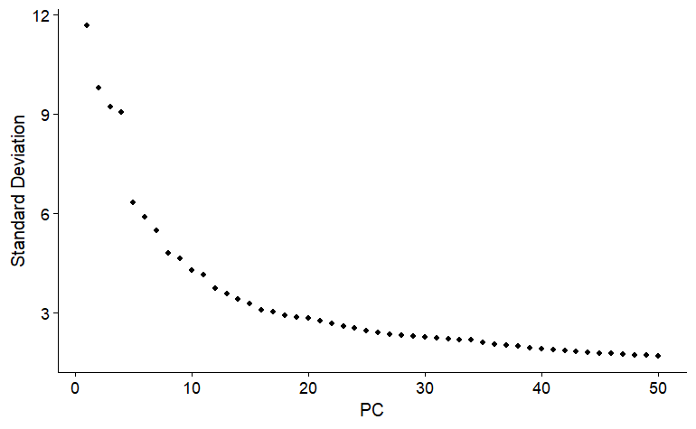

```r
ElbowPlot(sobj, ndims = 50)
```

# Olhando o Elbowplot acima percebemos que um bom número de PCs está entre 30-35. Dificilmente teremos grandes diferenças na clusterização se optarmos por usar 35 < nPCs. Podemos aplicar uma fórmula para verificar quanto de variância está sendo capturada com 30-35 PCs. Com 30 PCs, já capturamos 90% da variância.

```r
stdev <- sobj@reductions$pca@stdev
var <- stdev^2
sum(var[1:30])/ sum(var)
```

```
[1] 0.9080306
```

```r
sum(var[1:35])/ sum(var)
```

```
[1] 0.9372101
```

# Integração e remoção do efeito de batch com Harmony

```r
sobj <- RunHarmony(sobj, group.by.vars = "Patient")
```

```
Harmony 1/10
Harmony 2/10
Harmony 3/10
Harmony converged after 3 iterations
Warning: Invalid name supplied, making object name syntactically valid. New object name is Seurat..ProjectDim.RNA.harmony; see ?make.names for more details on syntax validity
```

# FindNeighbors, UMAP e visualização

```r
sobj <- FindNeighbors(object = sobj, dims = 1:30, reduction = "harmony")
sobj <- RunUMAP(object = sobj, dims = 1:30, reduction = "harmony")
```

```
Using method 'umap'
```

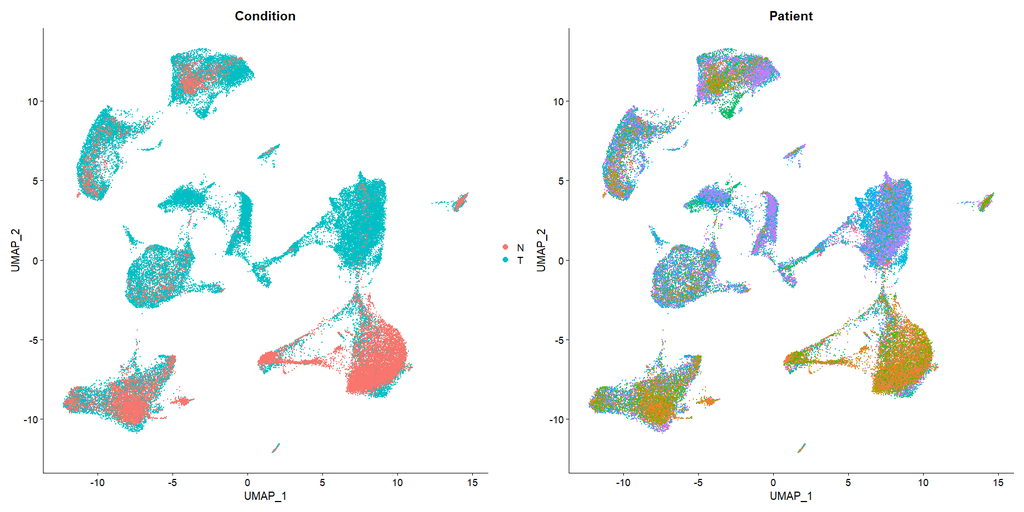

```r
p1<-DimPlot(object = sobj, reduction = "umap", group.by = "Condition")
p2<-DimPlot(object = sobj, reduction = "umap", group.by = "Patient")+NoLegend()
p1+p2
```

# Clusterização

```
Modularity Optimizer version 1.3.0 by Ludo Waltman and Nees Jan van Eck

Number of nodes: 57447
Number of edges: 2190660

Running Louvain algorithm...
```

```
Maximum modularity in 10 random starts: 0.9622
Number of communities: 17
Elapsed time: 17 seconds
```

```
Modularity Optimizer version 1.3.0 by Ludo Waltman and Nees Jan van Eck

Number of nodes: 57447
Number of edges: 2190660

Running Louvain algorithm...
```

```
Maximum modularity in 10 random starts: 0.9428
Number of communities: 22
Elapsed time: 16 seconds
```

```
Modularity Optimizer version 1.3.0 by Ludo Waltman and Nees Jan van Eck

Number of nodes: 57447
Number of edges: 2190660

Running Louvain algorithm...
```

```
Maximum modularity in 10 random starts: 0.9268
Number of communities: 30
Elapsed time: 14 seconds
```

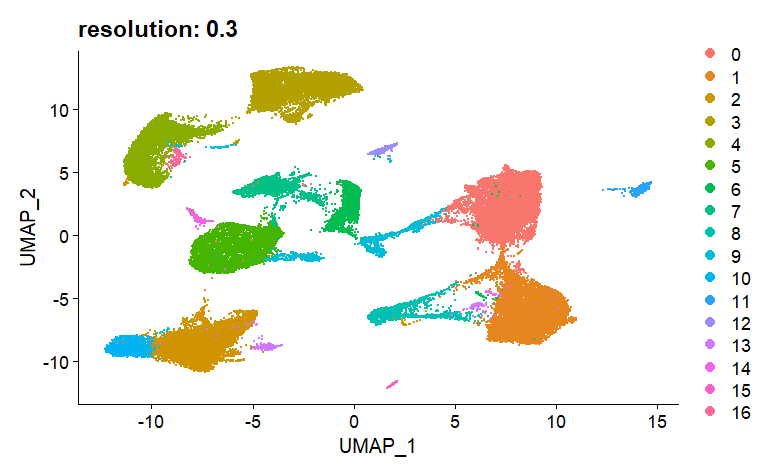

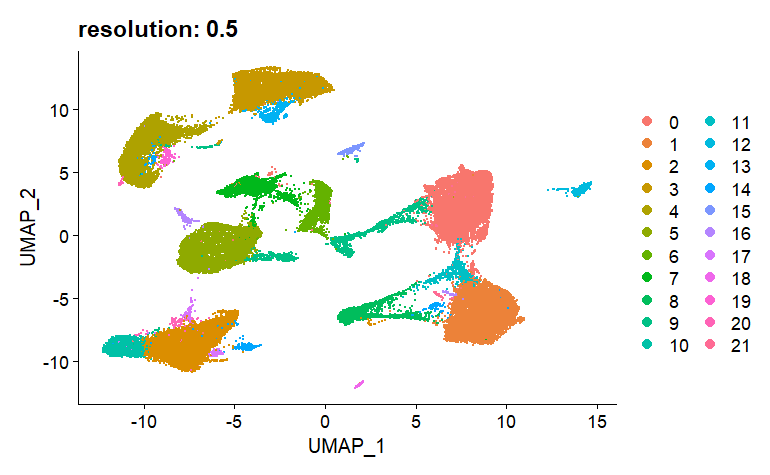

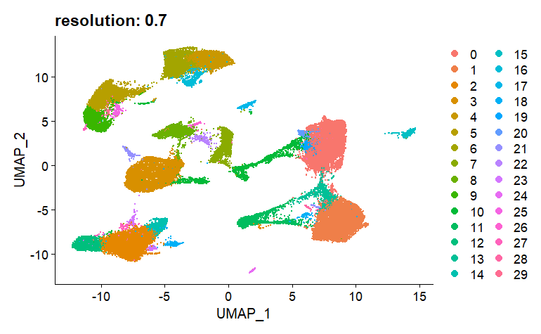

```r
for (i in c(0.3, 0.5, 0.7)) {
  sobj <- FindClusters(sobj, resolution = i, reduction = "harmony")
  print(DimPlot(sobj, reduction = "umap") + labs(title = paste0("resolution: ", i)))
}
```

# FeaturePlot, DotPlot e Heatmap para anotação dos tipos celulares

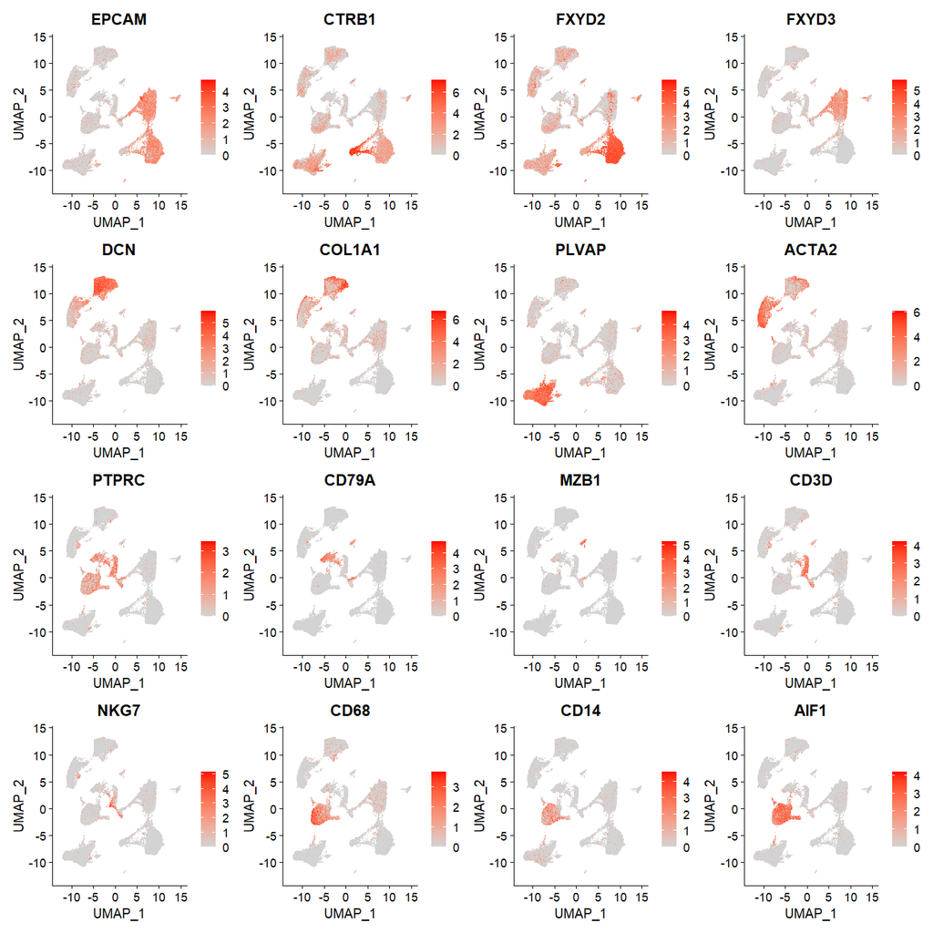

```r
features <- c("EPCAM", "CTRB1", "FXYD2", "FXYD3", "DCN", "COL1A1",
                               "PLVAP", "ACTA2", "PTPRC", "CD79A", "MZB1", "CD3D",
                               "NKG7", "CD68", "CD14", "AIF1")
FeaturePlot(sobj, features = features, cols = c("lightgrey", "red"), raster = TRUE, ncol = 4)
```

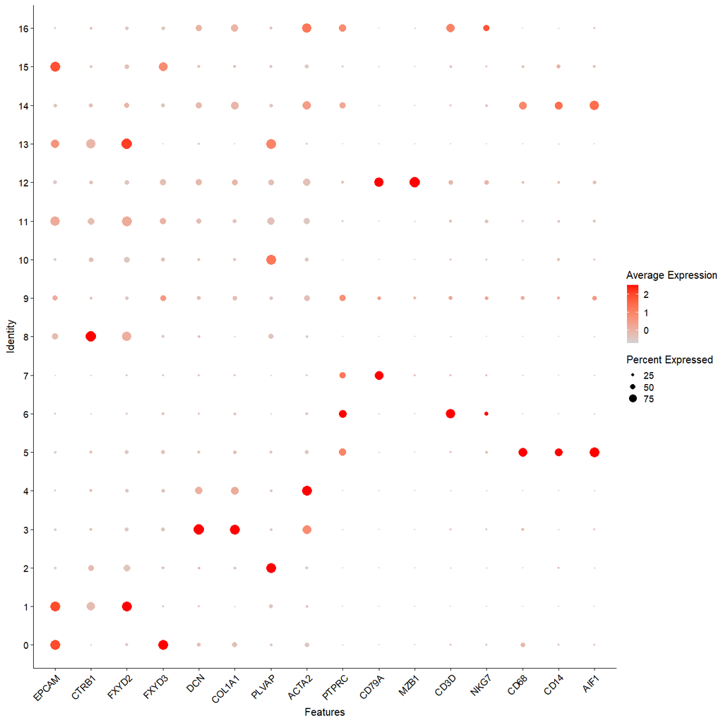

```r
DotPlot(object = sobj, features = features, idents = sobj$RNA_snn_res.0.3, cols = c("lightgrey", "red"))+RotatedAxis()
```

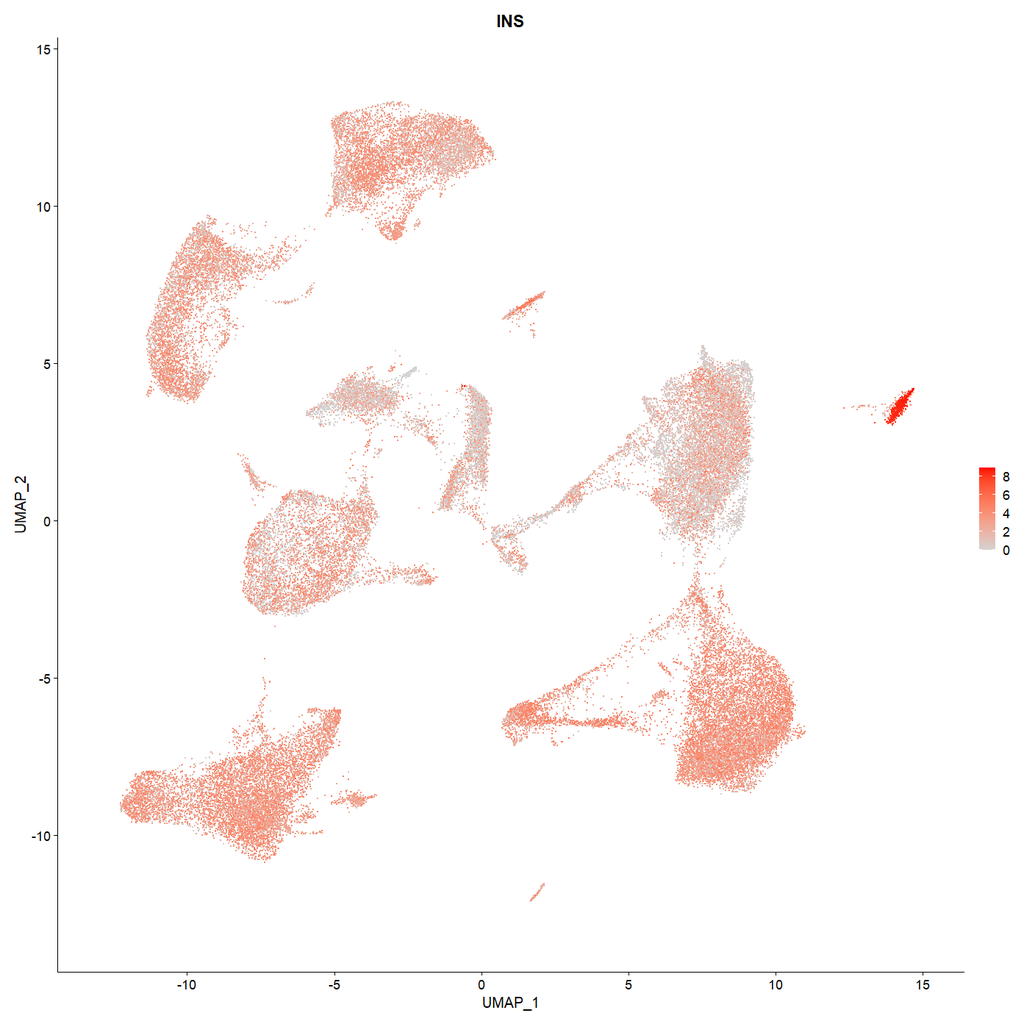

```r
FeaturePlot(sobj, features = "INS", cols = c("lightgrey", "red"))
```

# Expressão diferencial entre os clusters para identificação de marcadores

```r
markers <- FindAllMarkers(object = sobj, logfc.threshold = 0.5, test.use = "roc")
```

[output not shown]

[output cut: 40 more lines]

[output not shown]

[output not shown]

[output cut: 45 more lines]

[output not shown]

[output not shown]

[output cut: 39 more lines]

[output not shown]

[output not shown]

[output cut: 39 more lines]

[output not shown]

[output not shown]

[output cut: 44 more lines]

[output not shown]

[output not shown]

[output cut: 46 more lines]

[output not shown]

[output not shown]

[output cut: 43 more lines]

[output not shown]

[output not shown]

[output cut: 43 more lines]

[output not shown]

[output not shown]

[output cut: 40 more lines]

[output not shown]

[output not shown]

[output cut: 40 more lines]

[output not shown]

[output not shown]

[output cut: 45 more lines]

[output not shown]

[output not shown]

[output cut: 42 more lines]

[output not shown]

[output not shown]

[output cut: 44 more lines]

[output not shown]

[output not shown]

[output cut: 37 more lines]

[output not shown]

[output not shown]

[output cut: 37 more lines]

[output not shown]

[output not shown]

[output cut: 45 more lines]

[output not shown]

[output not shown]

[output cut: 33 more lines]

[output not shown]

```r
head(markers)
```

|  | myAUC | avg_diff | power | avg_log2FC | pct.1 | pct.2 | cluster | gene |
| --- | --- | --- | --- | --- | --- | --- | --- | --- |
| KRT19 | 0.969 | 2.294159 | 0.938 | 3.309772 | 0.992 | 0.477 | 0 | KRT19 |
| C19orf33 | 0.966 | 2.366515 | 0.932 | 3.414159 | 0.968 | 0.205 | 0 | C19orf33 |
| S100A6 | 0.962 | 1.939568 | 0.924 | 2.798206 | 1.000 | 0.947 | 0 | S100A6 |
| FXYD3 | 0.945 | 2.642967 | 0.890 | 3.812996 | 0.963 | 0.295 | 0 | FXYD3 |
| MUC1 | 0.929 | 1.802635 | 0.858 | 2.600653 | 0.938 | 0.263 | 0 | MUC1 |
| SMIM22 | 0.919 | 1.407618 | 0.838 | 2.030763 | 0.959 | 0.341 | 0 | SMIM22 |

# Assinaturas gênicas com UCell

```r
tnk_genes <- c("CD3D", "IL7R", "CD3E", "CD8A", "NKG7")
fibro_genes <- c("COL1A1", "DCN", "CTHRC1", "MMP11", "C7")
duct_genes <- c("CFTR", "AMBP", "FXYD2", "EPCAM")
stellate_genes <- c("ACTA2", "RGS5", "PDGFRB", "MYH11", "COL1A1")
myeloid_genes <- c("CD14", "CD68", "HLA-DRA", "AIF1", "APOE")
b_genes <- c("MS4A1", "CD19", "CD79A", "CD27", "CD79B")
plasma_genes <- c("MZB1", "IGLL5", "JCHAIN", "DERL3")
endo_genes <- c("PLVAP", "VWF", "CDH5", "CLDN5")
endoc_genes <- c("INS", "SST", "TTR")
malig_genes <- c("MUC1", "KRT19", "FXYD3", "SOX9", "TFF1", "TFF2", "TFF3")
acinar_genes <- c("CPB1", "SPINK1", "PRSS1", "CTRB1", "AMY2A", "TRY4")

cell_markers <- list()
cell_markers$Tnk <- c(tnk_genes)
cell_markers$Fibro <- c(fibro_genes)
cell_markers$Duct <- c(duct_genes)
cell_markers$Stellate <- c(stellate_genes)
cell_markers$Myeloid <- c(myeloid_genes)
cell_markers$Bcells <- c(b_genes)
cell_markers$Plasma <- c(plasma_genes)
cell_markers$Endothelial <- c(endo_genes)
cell_markers$Endocrine <- c(endoc_genes)
cell_markers$Malignant <- c(malig_genes)
cell_markers$Acinar <- c(acinar_genes)

sobj <- AddModuleScore_UCell(sobj, features = cell_markers)
signature.names <- paste0(names(cell_markers), "_UCell")
```

# Visualização dos scores

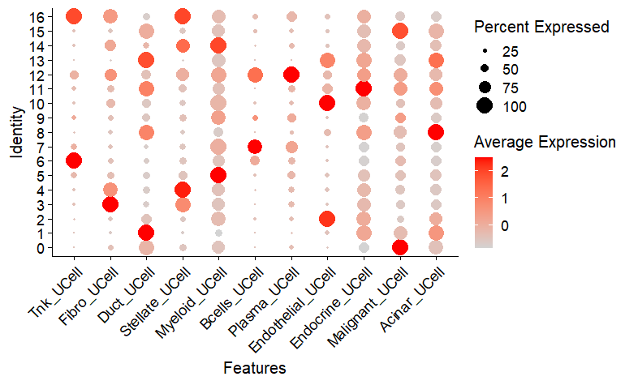

```r
DotPlot(sobj, features = signature.names, cols = c("lightgrey", "red"))+RotatedAxis()
```

# Salvando o dataframe com os marcadores

```r
write.table(markers,file='D:Scanpy/Workflow_A/roc_markers_seurat.csv',
  quote=F,row.names=F,col.names=F
)
```

# Anotação dos clusters

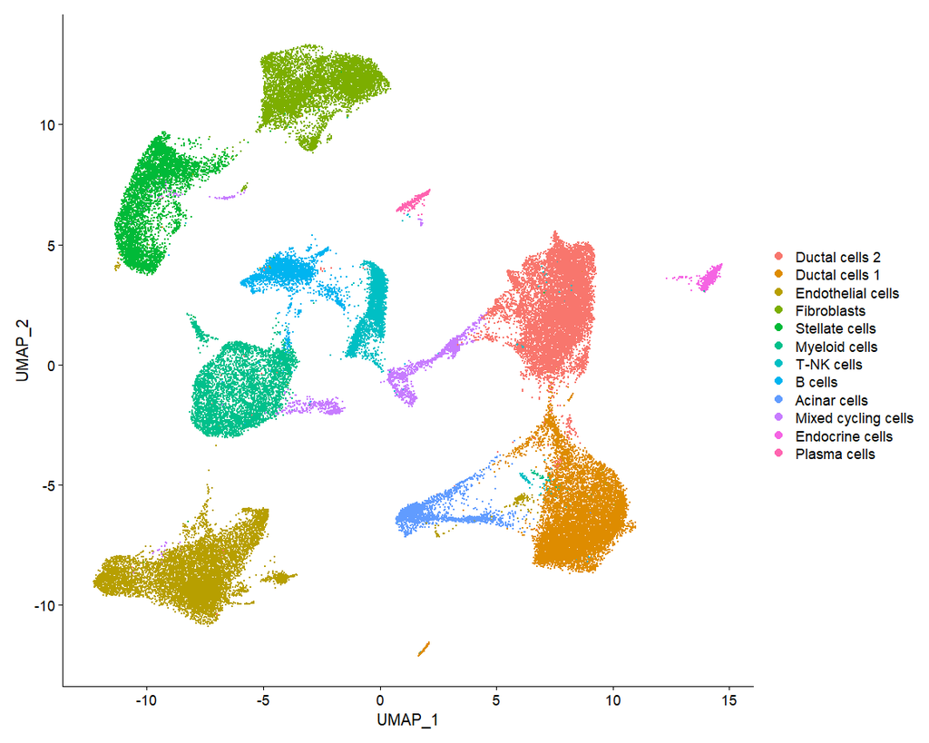

```r
sobj <- SetIdent(sobj, value = sobj$RNA_snn_res.0.3)
cell_ids <- c("Ductal cells 2", "Ductal cells 1", "Endothelial cells", "Fibroblasts",
              "Stellate cells", "Myeloid cells", "T-NK cells", "B cells", "Acinar cells",
              "Mixed cycling cells", "Endothelial cells", "Endocrine cells", "Plasma cells",
              "Endothelial cells", "Myeloid cells", "Ductal cells 1", "Stellate cells")
names(cell_ids) <- levels(sobj)
sobj <- RenameIdents(sobj, cell_ids)
sobj[["cell_type"]] <- Idents(object = sobj)
DimPlot(sobj, reduction = "umap")
```

# Salvando objeto Seurat

```r
saveRDS(object = sobj, file = 'D:/Scanpy/Workflow_A/seurat_peng.rds')
```

# Composição celular

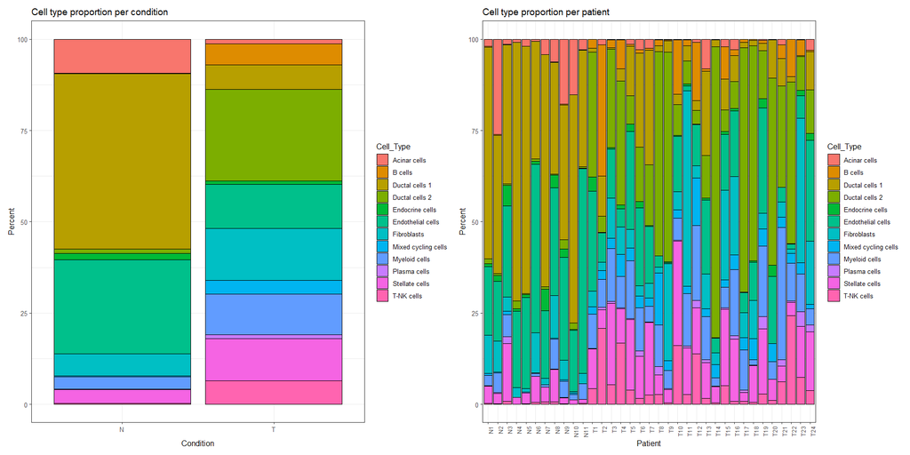

```r
composition1 <- table(Idents(sobj), sobj$Condition)
composition1 <- as.data.frame(composition1)
composition1$Var1 <- as.character(composition1$Var1)
composition1$Var2 <- as.character(composition1$Var2)
composition1 = composition1 %>% rename(Cell_Type = "Var1", Condition = "Var2") %>%
  group_by(Condition) %>%
  mutate(Percent = Freq / sum(Freq)*100)

composition2 <- table(Idents(sobj), sobj$Patient)
composition2 <- as.data.frame(composition2)
composition2$Var1 <- as.character(composition2$Var1)
composition2$Var2 <- as.character(composition2$Var2)
composition2 = composition2 %>% rename(Cell_Type = "Var1", Patient = "Var2") %>%
  group_by(Patient) %>%
  mutate(Percent = Freq / sum(Freq)*100)
composition2$Patient <- factor(composition2$Patient,
                                      levels = c("N1", "N2", "N3", "N4", "N5", "N6", "N7",
                                                 "N8", "N9", "N10", "N11", "T1", "T2", "T3",
                                                 "T4", "T5", "T6", "T7", "T8", "T9", "T10",
                                                 "T11", "T12", "T13", "T14", "T15", "T16", "T17",
                                                 "T18", "T19", "T20", "T21", "T22", "T23", "T24"))

p1 <- ggplot(composition1, aes(x = Condition, y = Percent, fill = Cell_Type)) +
  geom_bar(stat = "identity", color = "black") +
  theme_bw()+ggtitle("Cell type proportion per condition")

p2<-  ggplot(composition2, aes(x = Patient, y = Percent, fill = Cell_Type)) +
  geom_bar(stat = "identity", color = "black") +
  theme_bw()+theme(axis.text.x = element_text(angle = 90, size = 8, hjust = 1))+ggtitle("Cell type proportion per patient")

p1+p2
```